# HW2_TS_KatieBaerveldt

Katie B

9/8/2019

# **Homework 2: Part A**

### Question 1

1. Plot the time series and comment on its components (trend, cyclical, seasonality, random). Discuss the mean, variance, skewness, and kurtosis (four moments) of the time series.

Data import setup:

```r
library(tseries)
library(forecast)
library(zoo)
library(fBasics)
```

```r
library(xts)
library(ggplot2)
library(moments)
library(fpp2) #Part 2
library(seasonal)
alcohol <- read.table('C:/Users/kbaer/Desktop/Katie/Time Series (Fall A 2019)/Alcohol.csv', header=T, sep=',')

#alcohol
```

Data transformation:

```r
alcohol.ts = ts(data=alcohol$Alcohol.demand..log.spirits.consumption.per.head...UK..1870.1938, frequency = 3, start=c(1870,4), end=c(1938,12))

alcohol.zoo <- zoo(alcohol.ts)
```

Decomposing the time series:

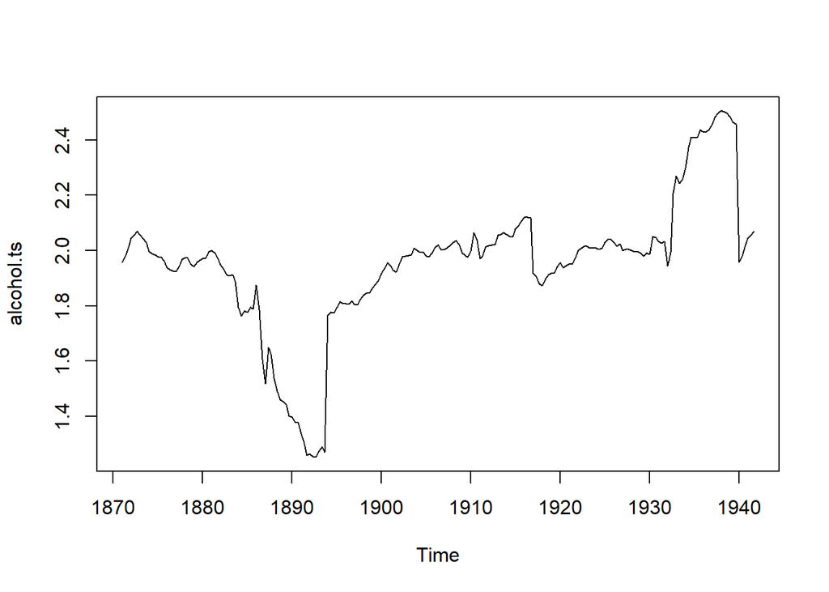

```r
plot(alcohol.ts)
```

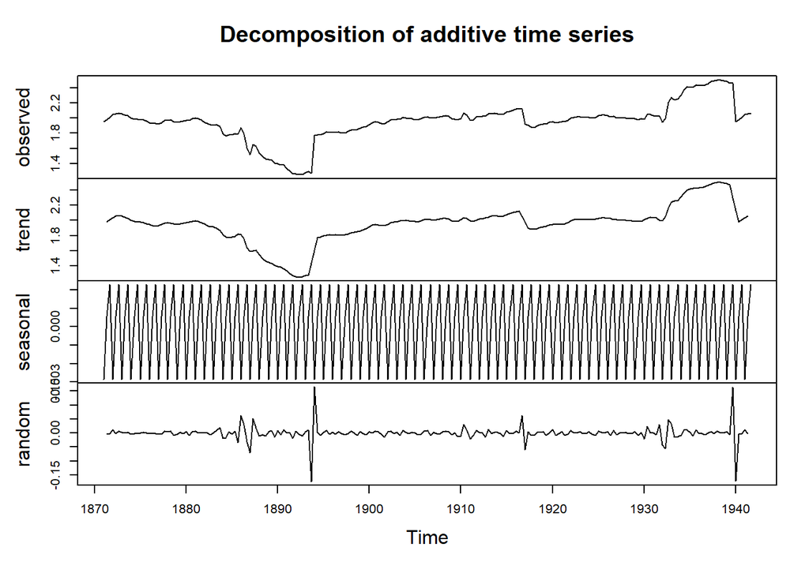

```r
plot(decompose(alcohol.ts))
```

More EDA:

```r
basicStats(alcohol.ts)
```

```
##             alcohol.ts
## nobs        213.000000
## NAs           0.000000
## Minimum       1.253000
## Maximum       2.505000
## 1. Quartile   1.909000
## 3. Quartile   2.029000
## Mean          1.952324
## Median        1.981000
## Sum         415.845000
## SE Mean       0.016855
## LCL Mean      1.919099
## UCL Mean      1.985549
## Variance      0.060513
## Stdev         0.245993
## Skewness     -0.610602
## Kurtosis      1.814195
```

Even though I’ve decomposed the original time series data, I’d like to do a seasonplot for a closer look on variation between time periods:

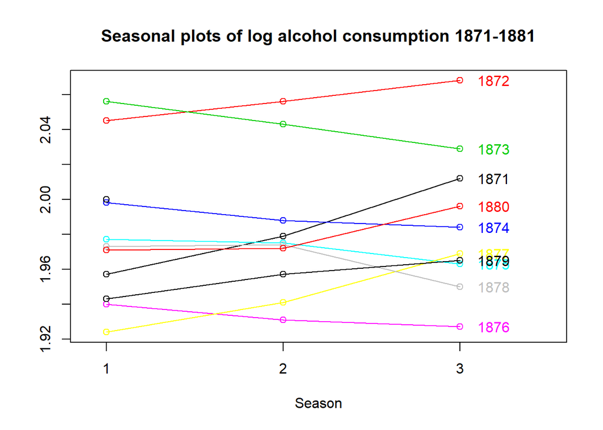

```r
seasonplot(window(alcohol.ts,start = 1871, end = 1881), year.labels = TRUE, col = 1:10, main = "Seasonal plots of log alcohol consumption 1871-1881")
```

For this I just wanted to see if there was a significant change in the first 10 years of the data. This isn’t the easiest vizualization to read, but I can see that there was a significant increase in consumption from 1871 to 1872, which climbs downward until 1876 and begins to slowly rise again. On a year-by-year basis, there seems to be a seasonal pattern of stagnant rise or fall in consumption until the beginning of the second “season”, although that is not true for every year.

I want to see what this seasonplot looks like with all of the data at once, so I will try the ggseasonplot method we used in HW 1:

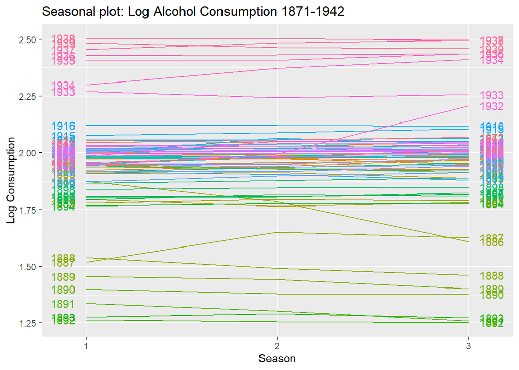

```r
ggseasonplot(alcohol.ts, year.labels=TRUE, year.labels.left=TRUE) +
  ylab("Log Consumption") +
  ggtitle("Seasonal plot: Log Alcohol Consumption 1871-1942")
```

This is still very messy, but I can clearly see that log consumption was highest in the 1930s and lowest in the late 1880s/early 1890s.

Now I will dissect the “four moments”:

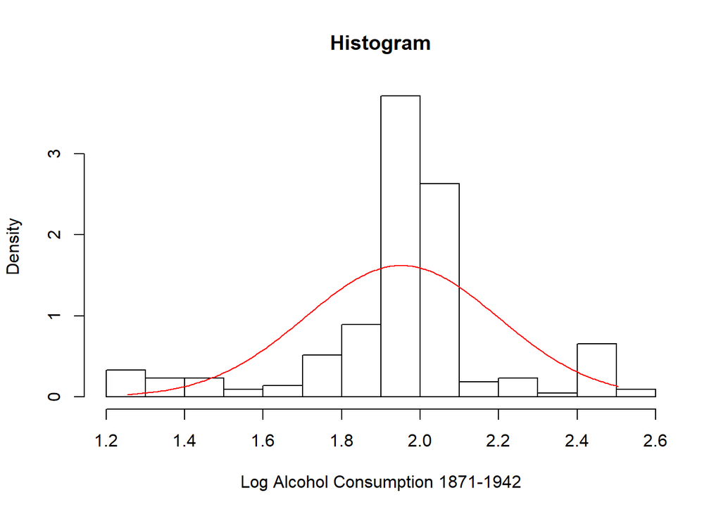

```r
hist(alcohol.ts, xlab="Log Alcohol Consumption 1871-1942", prob=TRUE, main="Histogram")
xfit<-seq(min(alcohol.ts),max(alcohol.ts), length=192)
# Why this length value? Tested other random values but could not determine how to select a value
yfit<-dnorm(xfit,mean=mean(alcohol.ts),sd=sd(alcohol.ts))
lines(xfit, yfit, col="red", lwd=1)
```

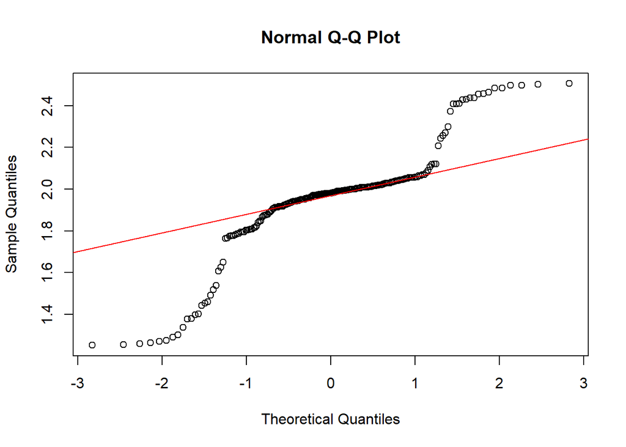

```r
qqnorm(alcohol.ts)
qqline(alcohol.ts, col = 2)
```

```r
skewness(alcohol.ts)
```

```
## [1] -0.6149269
```

```r
kurtosis(alcohol.ts)
```

```
## [1] 4.85972
```

Through the overview of the histogram and the Q-Q plot, it’s easy to see that this is not a normal distribution. The mean of the data lies around 1.96 and has high variance in density. The skewness of the tails also shows a great disparity, which is reflected in the steep kurtosis.

2. Examine the normality of the time series using the Jarque-Bera (JB) test. Please write out the null and alternative hypotheses and reach a conclusion. What can you do if the Alcohol time series is not normally distributed? What transformation can you do?

```r
normalTest(alcohol.ts,method=c("jb"))
```

```
##
## Title:
##  Jarque - Bera Normalality Test
##
## Test Results:
##   STATISTIC:
##     X-squared: 44.1185
##   P VALUE:
##     Asymptotic p Value: 2.629e-10
##
## Description:
##  Mon Sep 16 23:00:04 2019 by user: kbaer
```

H0 = Data is normally distributed (p > 0.05) H1 = Data is not normally distributed (p < 0.05)

Given this outcome, I would say that I reject the null hypothesis being that the data is normally distributed. It is clear that if I want to analyze this further as a time series, I would need to perform a transformation to the data. I will start by performing a Box Cox transformation.

The purpose is to simplify the patterns in the historical data by removing known sources of variation, and/or by making the pattern more consistent across the whole data set (“Forecasting: Principles and Practice”)

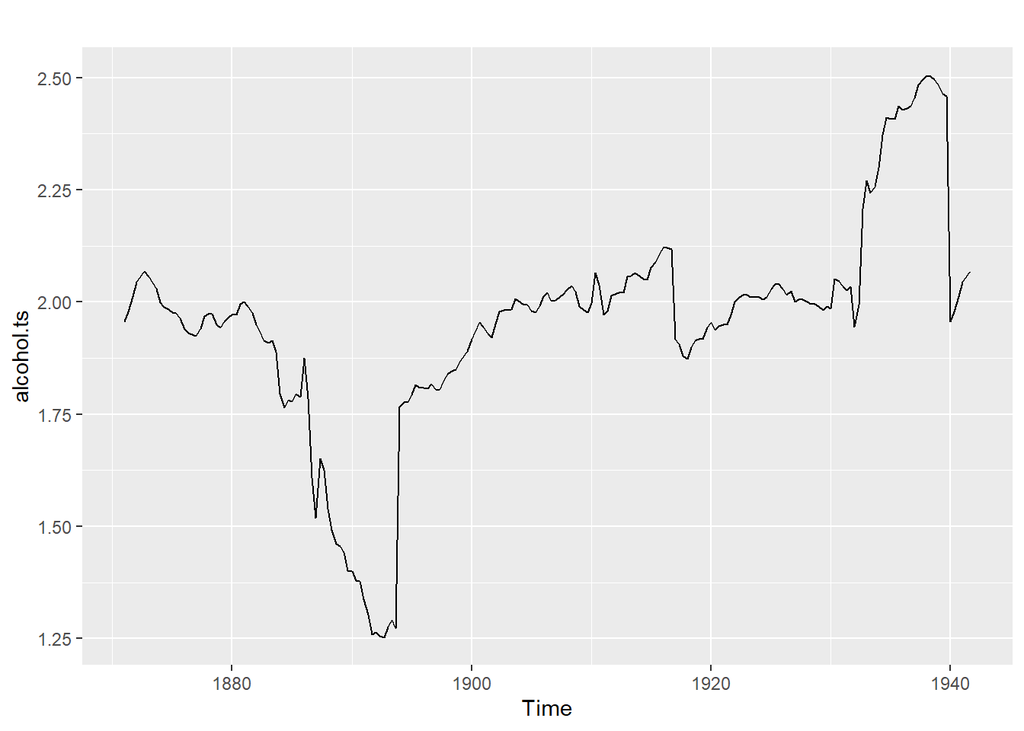

```r
autoplot(alcohol.ts) # Shows the original plot so we can compare against the adjusted plot #
```

```r
BoxCox.lambda(alcohol.ts)
```

```
## [1] 1.788414
```

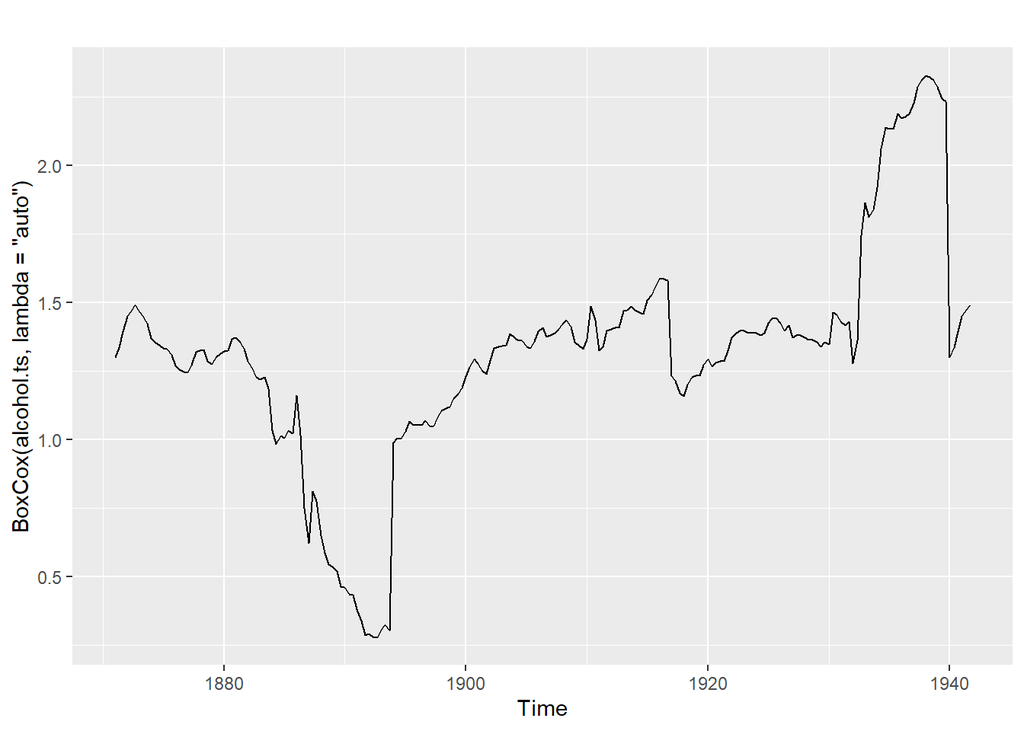

```r
autoplot(BoxCox(alcohol.ts, lambda="auto"))
```

```r
normalTest(BoxCox(alcohol.ts,lambda="auto"), method=c("jb"))
```

```
##
## Title:
##  Jarque - Bera Normalality Test
##
## Test Results:
##   STATISTIC:
##     X-squared: 22.8315
##   P VALUE:
##     Asymptotic p Value: 1.102e-05
##
## Description:
##  Mon Sep 16 23:00:05 2019 by user: kbaer
```

This didn’t have the level of success I was hoping for, so I will try another method and just take the natural log of the data:

```r
alcohol_log <- log(alcohol.ts)
normalTest(alcohol_log, method=c("jb"))
```

```
##
## Title:
##  Jarque - Bera Normalality Test
##
## Test Results:
##   STATISTIC:
##     X-squared: 124.3403
##   P VALUE:
##     Asymptotic p Value: < 2.2e-16
##
## Description:
##  Mon Sep 16 23:00:05 2019 by user: kbaer
```

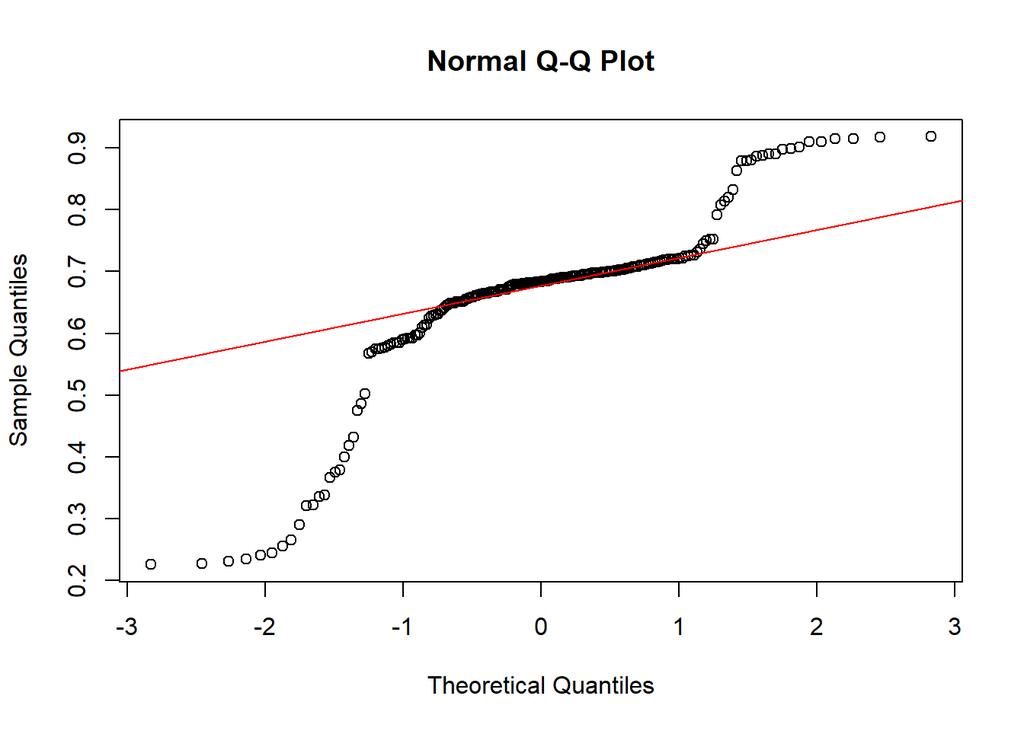

```r
qqnorm(alcohol_log)
qqline(alcohol_log, col = 2)
```

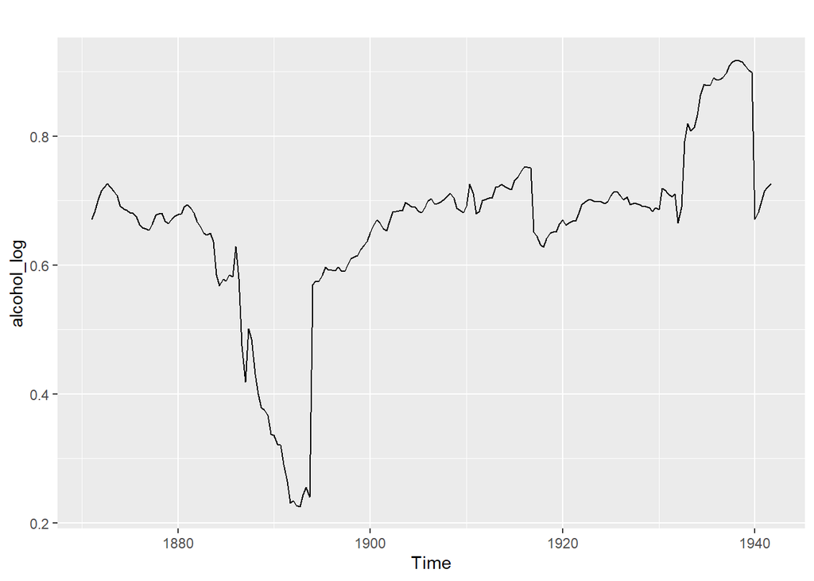

```r
autoplot(alcohol_log)
```

Not much of a transformation here either.

3. Check the serial correlation in the Alcohol time series using the ACFs and ACF plot (correlogram). Comment on what you see. Examine the serial correlation in the time series using the Ljung-Box test. Please write out the null and alternative hypotheses and reach a conclusion.

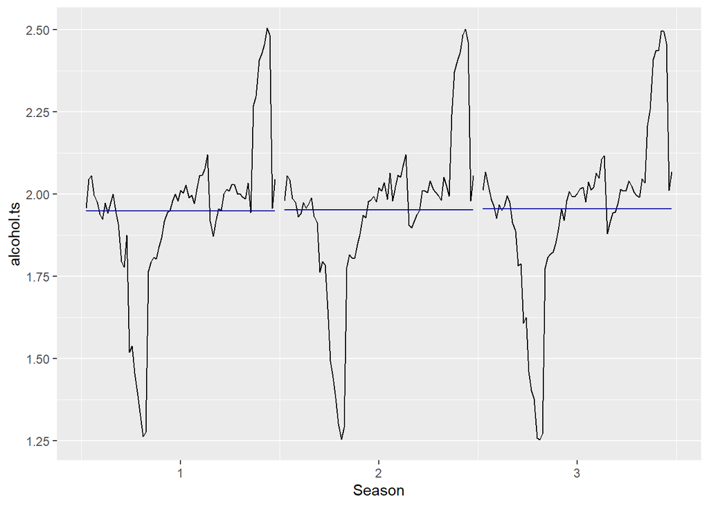

```r
ggsubseriesplot(alcohol.ts)
```

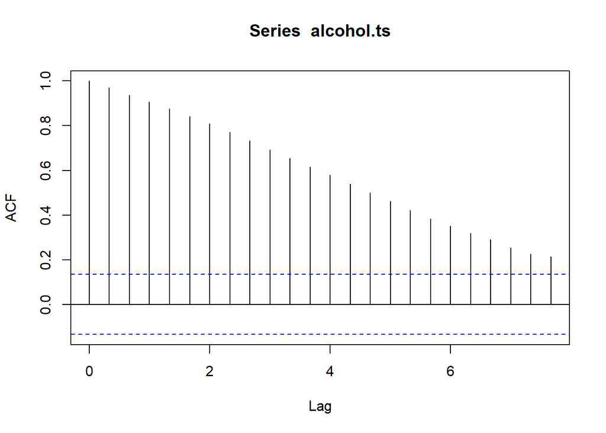

```r
acf(alcohol.ts)
```

```r
Box.test(alcohol.ts,lag=12,type='Ljung')
```

```
##
##  Box-Ljung test
##
## data:  alcohol.ts
## X-squared = 1658.6, df = 12, p-value < 2.2e-16
```

There is serial autocorrelation present in this data as seen through the correlation between periods and overall downward trend of the ACF plot. This implies that each observation is positively associated with its recent past, at least through the lags present in this data, but the association becomes weaker as the lags increase.

As far as alcohol consumption goes in a typical population, it’s apparent that drinking habits are not subject to much fluctuation. Consumption will increase slightly on weekends, or when the general population is not working such as holidays. The latter is more apparent in the data since this is taken on a yearly basis - case in point, alcohol consumption will show seasonality but there is no reason that a trend would be present unless external factors were at play. Overall consumption will only spike or drop dramatically if there is a shock event associated with it - in this case, there are two (Great Depression and Prohibition), so the data is skewed in both directions over this time frame.

### Question 2

Please complete ONLY questions a, b, c, and d of Exercise #2 (on the plastics data set) in Chapter 6 of Hyndman text. Link to Exercise: https://otexts.com/fpp2/decomposition-exercises.html. This question is worth 40 points. Be sure to load the fpp2 package to get the plastics data set.

1. Plot the time series of sales of product A. Can you identify seasonal fluctuations and/or a trend-cycle?

```r
?plastics #info on the data
```

```
## starting httpd help server ... done
```

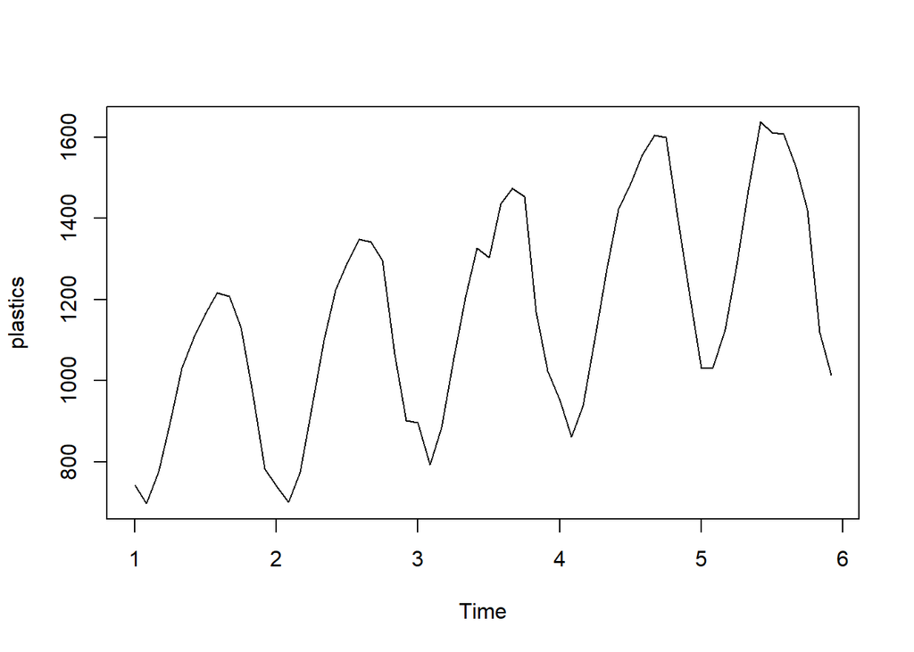

```r
plot(plastics)
```

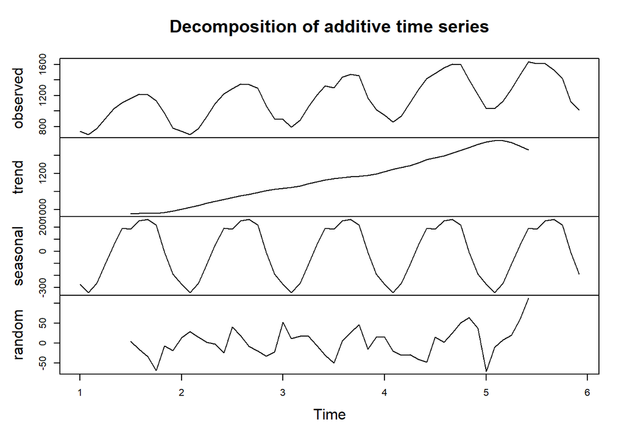

```r
plot(decompose(plastics))
```

2. Use a classical multiplicative decomposition to calculate the trend-cycle and seasonal indices.

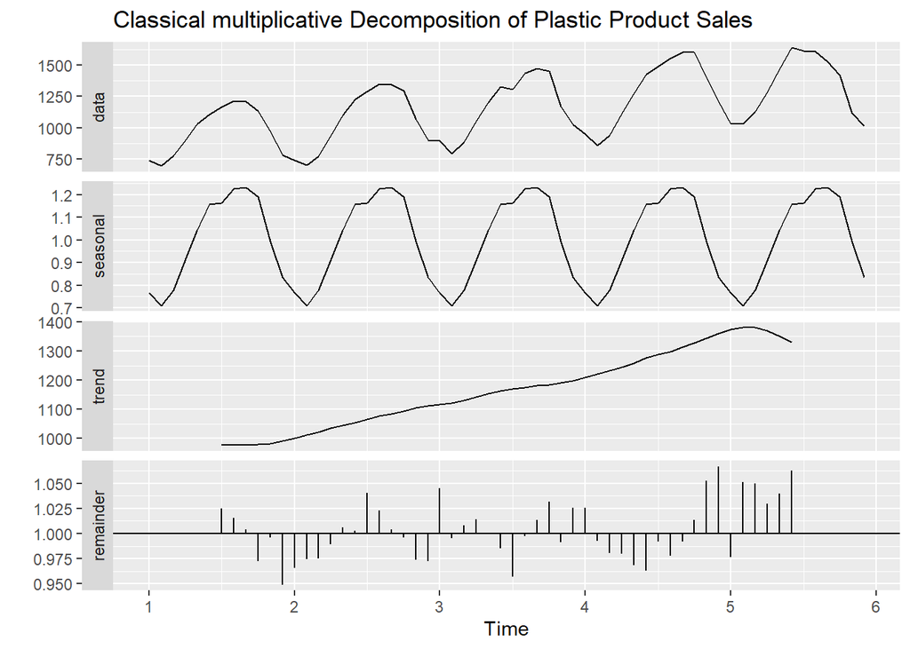

```r
plastics %>% decompose(type="multiplicative") %>%
  autoplot() + xlab("Time") +
  ggtitle("Classical multiplicative Decomposition of Plastic Product Sales")
```

c. Do the results support the graphical interpretation from part a?